# Decision Tree Model

Group #6

This page presents an exploration of survival status outcomes based on the analysis of patient data using Decision Tree with different feature selection strategies. We select the features by sorting the feature importance with decision tree.

We first fit in the decision tree model with all the features, the accuracy achieved **72.94%** wiith sensitivity of 77.14$, specificity 70.00%.

The tree plot is shown below:

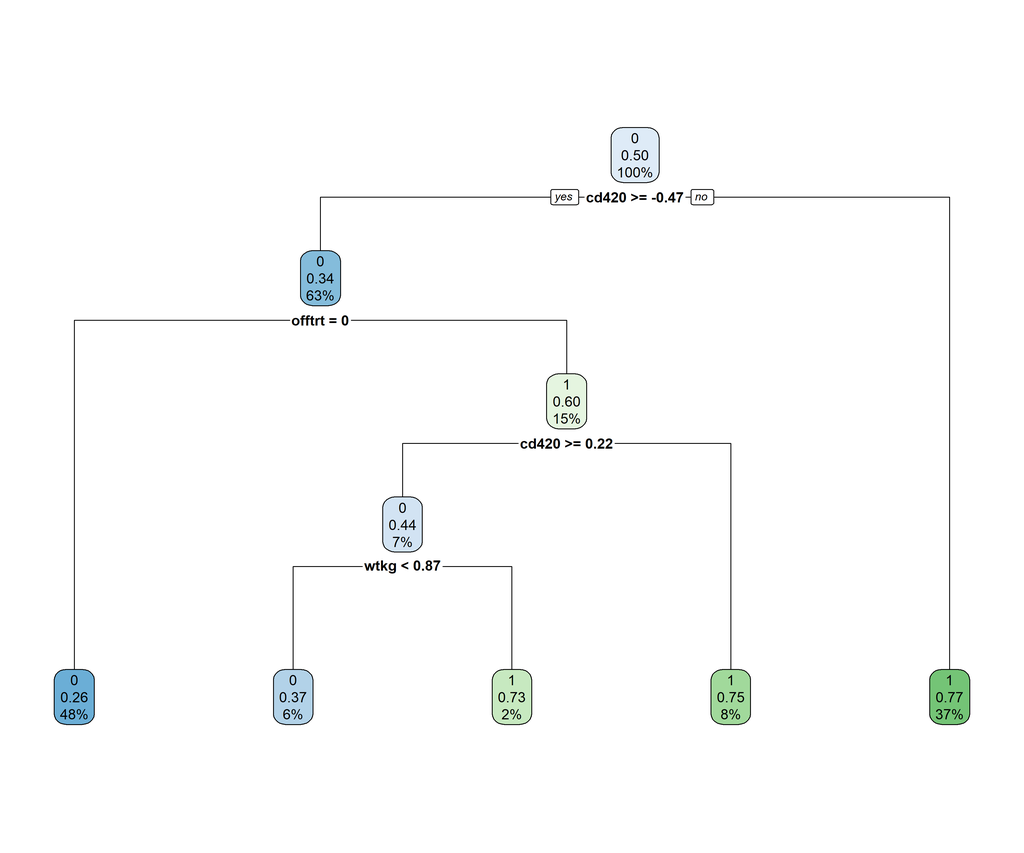

We sorted the feature by feature impoartance, and then we select the top 6 important features, “cd420”,“offtrt”,“age”, “preanti”, “cd40”,“gender”.

With the selected features, the accuracy achieved **72.94%** with sensitivity of 77.14%, specificity 70.00%

[figure not shown]

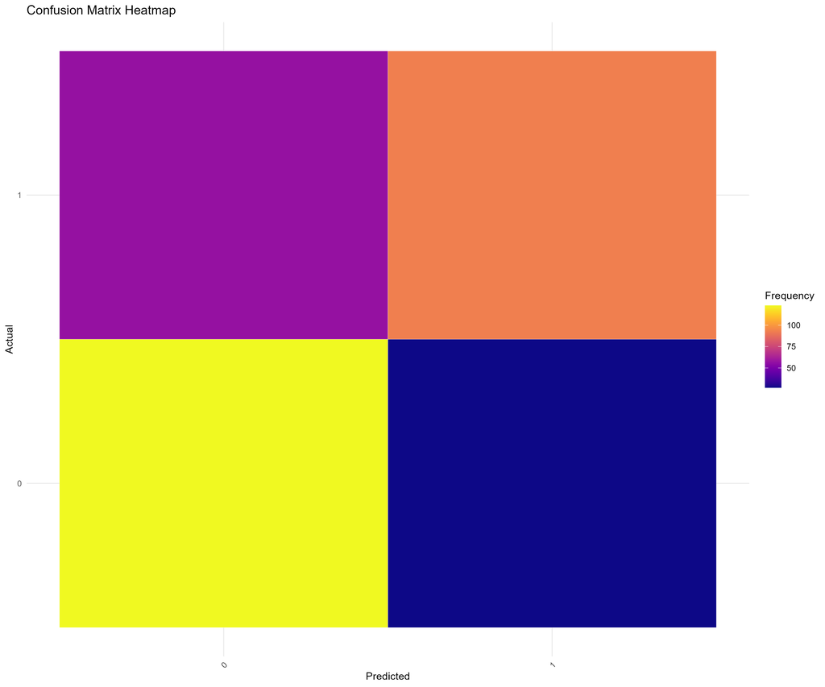

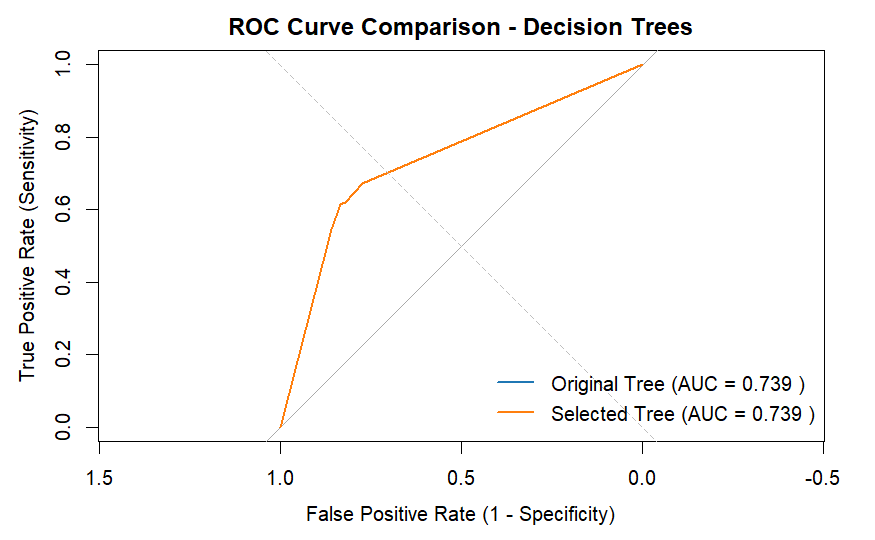

Both Decision Tree models has the exact same ROC curve with AUC value 0.739.

## Conclusion

With the selected feature from the feature importance function of decision, the accuracy, sensitivity and specificity score has not obviously improve. Thus we still decide to use the model fitted with all the features as our model outcome with an overall accuracy of **72.94%** wiith sensitivity of 77.14$, specificity 70.00%.